# House Prices Prediction

Ramya Deepthi Avula

January 10, 2019

Since the number of features in this dataset is high, it’s advised to load data using StringsAsFactors=False because there might be numeric features which might get converted to factors even if there is one error value which is a character.

```r
setwd("C:/MSBA/Career/Projects/HousePrices")
train <- read.csv(file="train.csv", stringsAsFactors = F)
test <- read.csv(file="test.csv", stringsAsFactors = F)
```

# Data Preprocessing

Before converting all characters to factors, let’s join train and test sets so they have same levels in all factor variables. This helps to avoid error during prediction due to new levels in any features in test dataset.

We have to remove target variable from train so that it has the same number of variables as test.

```r
data <- rbind(train[,-81],test)
data <- data[-1] #Removing Id from data
```

Note that the first 1460 rows are of train and the records starting from 1461 belong to test dataset.

Data dictionary mentions that NA=None for below variables.

Alley, BsmtQual, BsmtCond, BsmtExposure, BsmtFinType1, BsmtFinTyp2, FireplaceQu, GarageType, GarageFinish, GarageQual, GarageCond, PoolQC, Fence, MiscFeature.

Let’s create a vector of names of variables where NAs are not missing values.

```r
not_NA <- c("Alley", "BsmtQual", "BsmtCond", "BsmtExposure", "BsmtFinType1", "BsmtFinType2", "FireplaceQu", "GarageType", "GarageFinish", "GarageQual", "GarageCond", "PoolQC", "Fence", "MiscFeature")
```

These NAs shall be replaced by “None” through a user defined function.

```r
replacena <- function(x) {
  ifelse(is.na(x),"None",x)
} #defining replacena function

data[not_NA] <- data.frame(lapply(data[not_NA],replacena)) #applying replacena
```

Some of the values in other variables are related to the “NA”s in above variables. For example, if there’s NA in BsmtQual which means there is no basement, then BsmtFinSF1 will be 0 for the observation. So, we have to look at NAs in these related variables as well. I will do that at a later stage after correcting datatypes

Since there are too many variables that need to be converted to factors, getting all the column numbers is time-consuming. Since we have seen in the summary there are no error values (characters in numeric variables), I’ll write the data so far to a csv and load the same into R using StringsAsFactors=T.

```r
write.csv(data,'df.csv')
data <- read.csv(file="df.csv", stringsAsFactors = T)
```

writing to a csv file has created an ID column named “X”, we don’t need this.

```r
data <- subset(data, select = -X)
summary(data)
```

```
##    MSSubClass        MSZoning     LotFrontage        LotArea
##  Min.   : 20.00   C (all):  25   Min.   : 21.00   Min.   :  1300
##  1st Qu.: 20.00   FV     : 139   1st Qu.: 59.00   1st Qu.:  7478
##  Median : 50.00   RH     :  26   Median : 68.00   Median :  9453
##  Mean   : 57.14   RL     :2265   Mean   : 69.31   Mean   : 10168
##  3rd Qu.: 70.00   RM     : 460   3rd Qu.: 80.00   3rd Qu.: 11570
##  Max.   :190.00   NA's   :   4   Max.   :313.00   Max.   :215245
##                                  NA's   :486
##   Street      Alley      LotShape   LandContour  Utilities
##  Grvl:  12   Grvl: 120   IR1: 968   Bnk: 117    AllPub:2916
##  Pave:2907   None:2721   IR2:  76   HLS: 120    NoSeWa:   1
##              Pave:  78   IR3:  16   Low:  60    NA's  :   2
##                          Reg:1859   Lvl:2622
##
##
##
##    LotConfig    LandSlope   Neighborhood    Condition1     Condition2
##  Corner : 511   Gtl:2778   NAmes  : 443   Norm   :2511   Norm   :2889
##  CulDSac: 176   Mod: 125   CollgCr: 267   Feedr  : 164   Feedr  :  13
##  FR2    :  85   Sev:  16   OldTown: 239   Artery :  92   Artery :   5
##  FR3    :  14              Edwards: 194   RRAn   :  50   PosA   :   4
##  Inside :2133              Somerst: 182   PosN   :  39   PosN   :   4
##                            NridgHt: 166   RRAe   :  28   RRNn   :   2
##                            (Other):1428   (Other):  35   (Other):   2
##    BldgType      HouseStyle    OverallQual      OverallCond
##  1Fam  :2425   1Story :1471   Min.   : 1.000   Min.   :1.000
##  2fmCon:  62   2Story : 872   1st Qu.: 5.000   1st Qu.:5.000
##  Duplex: 109   1.5Fin : 314   Median : 6.000   Median :5.000
##  Twnhs :  96   SLvl   : 128   Mean   : 6.089   Mean   :5.565
##  TwnhsE: 227   SFoyer :  83   3rd Qu.: 7.000   3rd Qu.:6.000
##                2.5Unf :  24   Max.   :10.000   Max.   :9.000
##                (Other):  27
##    YearBuilt     YearRemodAdd    RoofStyle       RoofMatl
##  Min.   :1872   Min.   :1950   Flat   :  20   CompShg:2876
##  1st Qu.:1954   1st Qu.:1965   Gable  :2310   Tar&Grv:  23
##  Median :1973   Median :1993   Gambrel:  22   WdShake:   9
##  Mean   :1971   Mean   :1984   Hip    : 551   WdShngl:   7
##  3rd Qu.:2001   3rd Qu.:2004   Mansard:  11   ClyTile:   1
##  Max.   :2010   Max.   :2010   Shed   :   5   Membran:   1
##                                               (Other):   2
```

[output cut: 89 more lines]

```
##  GdPrv: 118   Gar2:   5   Min.   :    0.00   Min.   : 1.000
##  GdWo : 112   None:2814   1st Qu.:    0.00   1st Qu.: 4.000
##  MnPrv: 329   Othr:   4   Median :    0.00   Median : 6.000
##  MnWw :  12   Shed:  95   Mean   :   50.83   Mean   : 6.213
##  None :2348   TenC:   1   3rd Qu.:    0.00   3rd Qu.: 8.000
##                           Max.   :17000.00   Max.   :12.000
##
##      YrSold        SaleType    SaleCondition
##  Min.   :2006   WD     :2525   Abnorml: 190
##  1st Qu.:2007   New    : 239   AdjLand:  12
##  Median :2008   COD    :  87   Alloca :  24
##  Mean   :2008   ConLD  :  26   Family :  46
##  3rd Qu.:2009   CWD    :  12   Normal :2402
##  Max.   :2010   (Other):  29   Partial: 245
##                 NA's   :   1
```

## Correcting data types

Since this is the beginning of EDA and we haven’t seen the variables in detail, let’s work on each variable individually with the help of summary and data dictionary.

All data types are correct except MSSubClass and MoSold.

Apart from data types, I also looked at variables that might be related. Let’s make a note of everything observed now and work on it step by step.

1. Near zero variance- Utilities,Condition2, RoofMatl
2. Ordered Factors- ExterQual, ExterCond, BsmtQual, BsmtCond, HeatingQC, KitchenQual, FireplaceQu, GarageQual, GarageCond, PoolQC. 3.GarageYrBlt is extending upto 2207 which is definitely wrong. It shouldn’t be greater than 2010 and also GarageYrBlt<YrSold. 4.Basement and Garage related variables which are related to the variables where NAs were converted to None.
3. GrLivArea is living area above ground as per dictionary. So let’s see if it equals the sum of X1stFlrSF & X2ndFlrSF or X1stFlrSF, X2ndFlrSF & LowQualFinSF.
4. Let’s check correlation of all bathroom variables with SalePrice. If the correlation for each of them is less, we can combine all of these and eliminate individual variables. 6.Check frequencies of all Porch and Pool variables. Check correlation/anova of these with SalePrice. If there isn’t much relation, club these into single variable.
5. YrSold itself doesn’t make much sense in terms of affecting saleprice but age of the house (based on when it’s built/ remodeled) when it was sold should make sense. Check correlation of both with SalePrice and transform the variable accordingly.
6. Correlation with SalePrice for BedroomAbvGr, KitchenAbvGr, TotRmsAbvGrd. Also, if BedroomAbvGr+KitchenAbvGr=TotRmsAbvGrd. If correlation is less for BedroomAbvGr and KitchenAbvGr and if the above condition satisfies, we can get rid of the individual variables and keep only TotRmsAbvGrd.
7. Check relationship between OverallCond and OverallQual.
8. Relationship between SalePrice and YearBuilt/YearRemod.
9. Relationship between MasVnrType and MasVnrArea.
10. Relationship between ExterQual and ExterCOnd.
11. Correlation between BedroomAbvGr and TotRmsAbvGrd.
12. Correlation between GarageCars & GarageArea.
13. Relationships between GarageQual & GarageCond & GarageFinish

```r
data[,c("MSSubClass","MoSold")] <- lapply(data[,c("MSSubClass","MoSold")], factor)
```

## Near Zero Variance

Let’s delete the variables with obvious near zero variance. These can be seen directly in the summary.

```r
data <- subset(data, select=-c(Utilities,Condition2, RoofMatl))
```

## Ordered Factors

A few factor variables can be converted to ordered factors. Some of these have same levels, we can change them to ordered factors together, but a few other have to be converted individually.

```r
ordered_factors1 <- c("ExterQual", "ExterCond", "BsmtQual", "BsmtCond","HeatingQC", "KitchenQual", "FireplaceQu", "GarageQual", "GarageCond", "PoolQC")
order1 <- function(x) {ordered(x,levels=c("None","Po","Fa","TA","Gd","Ex"))}
data[,ordered_factors1] <- lapply(data[,ordered_factors1], order1)

ordered_factors2 <- c("BsmtFinType1","BsmtFinType2")
order2 <- function(x) {ordered(x,levels=c("None","Unf","LwQ","Rec","BLQ","ALQ","GLQ"))}
data[,ordered_factors2] <- lapply(data[,ordered_factors2], order2)

data$BsmtExposure <- ordered(data$BsmtExposure,levels=c("None","No", "Mn", "Av","Gd"))
```

## GarageYrBlt

```r
summary(data$GarageYrBlt)
```

```
##    Min. 1st Qu.  Median    Mean 3rd Qu.    Max.    NA's
##    1895    1960    1979    1978    2002    2207     159
```

```r
summary(data$YrSold)
```

```
##    Min. 1st Qu.  Median    Mean 3rd Qu.    Max.
##    2006    2007    2008    2008    2009    2010
```

```r
sum(data$GarageYrBlt>data$YrSold,na.rm = T)
```

```
## [1] 2
```

Let’s change all values >2010 and >YrSold to NA

```r
data$GarageYrBlt[data$GarageYrBlt>2010 | data$GarageYrBlt>data$YrSold]<- NA
```

## No Basement

Now let’s look at the variables related to the variables where NAs are converted to None.

```r
summary(subset(data,BsmtQual=="None")[,c("BsmtFinSF1","BsmtFinSF2", "BsmtUnfSF","TotalBsmtSF","BsmtFullBath", "BsmtHalfBath")])
```

```
##    BsmtFinSF1   BsmtFinSF2   BsmtUnfSF        TotalBsmtSF
##  Min.   :0    Min.   :0    Min.   :  0.000   Min.   :  0.000
##  1st Qu.:0    1st Qu.:0    1st Qu.:  0.000   1st Qu.:  0.000
##  Median :0    Median :0    Median :  0.000   Median :  0.000
##  Mean   :0    Mean   :0    Mean   :  6.612   Mean   :  6.612
##  3rd Qu.:0    3rd Qu.:0    3rd Qu.:  0.000   3rd Qu.:  0.000
##  Max.   :0    Max.   :0    Max.   :356.000   Max.   :356.000
##  NA's   :1    NA's   :1    NA's   :1         NA's   :1
##   BsmtFullBath  BsmtHalfBath
##  Min.   :0     Min.   :0
##  1st Qu.:0     1st Qu.:0
##  Median :0     Median :0
##  Mean   :0     Mean   :0
##  3rd Qu.:0     3rd Qu.:0
##  Max.   :0     Max.   :0
##  NA's   :2     NA's   :2
```

A few records still have NA values, these can be converted to 0 since there is no basement for these observations. Also, looking at max values, BsmtUnfSF and TotalBsmtSF are non-zero for at least one observation. They have to be converted to 0.

```r
data[c("BsmtFinSF1", "BsmtFinSF2", "BsmtUnfSF", "TotalBsmtSF","BsmtFullBath","BsmtHalfBath")][is.na(data[c("BsmtFinSF1", "BsmtFinSF2", "BsmtUnfSF", "TotalBsmtSF","BsmtFullBath","BsmtHalfBath")])] <- 0

data$BsmtUnfSF <- ifelse(data$BsmtQual=="None",0,data$BsmtUnfSF)
data$TotalBsmtSF <- ifelse(data$BsmtQual=="None",0,data$TotalBsmtSF)
```

## No Garage

```r
summary(subset(data,GarageType=="None")[,c("GarageYrBlt","GarageFinish", "GarageCars", "GarageArea","GarageQual","GarageCond")])
```

```
##   GarageYrBlt  GarageFinish   GarageCars   GarageArea GarageQual
##  Min.   : NA   Fin :  0     Min.   :0    Min.   :0    None:157
##  1st Qu.: NA   None:157     1st Qu.:0    1st Qu.:0    Po  :  0
##  Median : NA   RFn :  0     Median :0    Median :0    Fa  :  0
##  Mean   :NaN   Unf :  0     Mean   :0    Mean   :0    TA  :  0
##  3rd Qu.: NA                3rd Qu.:0    3rd Qu.:0    Gd  :  0
##  Max.   : NA                Max.   :0    Max.   :0    Ex  :  0
##  NA's   :157
##  GarageCond
##  None:157
##  Po  :  0
##  Fa  :  0
##  TA  :  0
##  Gd  :  0
##  Ex  :  0
##
```

Everything is alright here except GarageYrBlt

Let’s remove the NAs in GarageYrBlt. This is a numeric variable, but replacing NA with 0 will be wrong since it means Year 0. I’ll transform GarageYrBlt to GarageAge and make it 0 for houses with no garage. Age will be calculated based on year sold because that’s the age that matters.

```r
data$GarageAge <- data$YrSold-data$GarageYrBlt
summary(data$GarageAge)
```

```
##    Min. 1st Qu.  Median    Mean 3rd Qu.    Max.    NA's
##    0.00    6.00   29.00   29.77   48.00  114.00     161
```

Now let’s change relevant NAs to 0

```r
data$GarageAge[data$GarageType=="None"] <- 0
data$GarageYrBlt <-NULL
```

## Above ground living area

```r
cor(data$X1stFlrSF+data$X2ndFlrSF+data$LowQualFinSF, data$GrLivArea)
```

```
## [1] 1
```

Check correlation of these variables with SalePrice for train dataset.

```r
cor(train$SalePrice, train$X1stFlrSF)
```

```
## [1] 0.6058522
```

```r
cor(train$SalePrice, train$X2ndFlrSF)
```

```
## [1] 0.3193338
```

```r
cor(train$SalePrice, train$LowQualFinSF)
```

```
## [1] -0.02560613
```

```r
cor(train$SalePrice, train$GrLivArea)
```

```
## [1] 0.7086245
```

```r
cor(train$GrLivArea, train$X1stFlrSF)
```

```
## [1] 0.566024
```

Based on these corrrelations, I have decided to remove LowQualFinSF. Rest of the variables have considerable correlation with the target variable and so will be handled at a later stage.

```r
data <- subset(data, select=-LowQualFinSF)
```

## Bath Variables

```r
cor(train$SalePrice, train$BsmtFullBath)
```

```
## [1] 0.2271222
```

```r
cor(train$SalePrice, train$BsmtHalfBath)
```

```
## [1] -0.01684415
```

```r
cor(train$SalePrice, train$FullBath)
```

```
## [1] 0.5606638
```

```r
cor(train$SalePrice, train$HalfBath)
```

```
## [1] 0.2841077
```

```r
cor(train$SalePrice, 0.5*train$HalfBath+train$FullBath+0.5*train$BsmtHalfBath+train$BsmtFullBath)
```

```
## [1] 0.6317311
```

```r
cor(train$FullBath,0.5*train$HalfBath+train$FullBath+0.5*train$BsmtHalfBath+train$BsmtFullBath)
```

```
## [1] 0.6941971
```

Except FullBath, rest of the variables have very less correlation with SalePrice. And the combination of all these variables have higher correlation. So, I will combine all these variables into “TotalBath” and delete the individual variables.

```r
data$TotalBath <- data$BsmtFullBath+data$FullBath+0.5*(data$BsmtHalfBath+data$HalfBath)
data = subset(data, select = -c(BsmtHalfBath,BsmtFullBath,HalfBath))
```

## Wood Deck and Porch

Let’s check the frequency of non-zero values in the Porch variables.

```r
sum(train$OpenPorchSF>0)
```

```
## [1] 804
```

```r
sum(train$X3SsnPorch>0)
```

```
## [1] 24
```

```r
sum(train$ScreenPorch>0)
```

```
## [1] 116
```

```r
sum(train$EnclosedPorch>0)
```

```
## [1] 208
```

```r
cor(train$SalePrice, train$WoodDeckSF)
```

```
## [1] 0.3244134
```

```r
cor(train$SalePrice, train$OpenPorchSF)
```

```
## [1] 0.3158562
```

```r
cor(train$SalePrice, train$X3SsnPorch)
```

```
## [1] 0.04458367
```

```r
cor(train$SalePrice, train$ScreenPorch)
```

```
## [1] 0.1114466
```

```r
cor(train$SalePrice, train$EnclosedPorch)
```

```
## [1] -0.128578
```

```r
cor(train$SalePrice, train$X3SsnPorch+train$ScreenPorch+train$EnclosedPorch)
```

```
## [1] -0.00406257
```

It looks like it’s better to not make any transformations but X3SsnPorch could be removed.

```r
data <- subset(data,select=-X3SsnPorch)
```

## YrSold, YearBuilt, YearRemodAdd

```r
cor(train$SalePrice, train$YearBuilt)
```

```
## [1] 0.5228973
```

```r
cor(train$SalePrice,train$YearRemodAdd)
```

```
## [1] 0.507101
```

```r
cor(train$SalePrice, train$YrSold)
```

```
## [1] -0.02892259
```

As expected Year sold has little relation with sale price. Since both Year built and Year remodeled have nearly same correlation with saleprice, age of house in the year sold will be calculated using weighted average of these 2. And let’s give a little more weight to Yearbuilt. I’m choosing their correlation with SalePrice as weights.

Before creating the new variable let’s check if yrSold>YearBuilt and YearRemodAdd.

```r
sum(data$YrSold < data$YearBuilt)
```

```
## [1] 1
```

```r
sum(data$YrSold <data$YearRemodAdd)
```

```
## [1] 3
```

There are upto 4 cases that need to be looked into.

```r
subset(data, YrSold < YearBuilt | YrSold < YearRemodAdd)[,c("YrSold","YearBuilt","YearRemodAdd")]
```

```
##      YrSold YearBuilt YearRemodAdd
## 524    2007      2007         2008
## 2296   2007      2007         2008
## 2550   2007      2008         2009
```

```r
data$YrSold <- ifelse(data$YrSold<data$YearBuilt | data$YrSold<data$YearRemodAdd, NA, data$YrSold)
```

Let’s create the HouseAge variable that gives the age of house when it’s sold

```r
data$HouseAge <- data$YrSold-(data$YearBuilt*0.523+data$YearRemodAdd*0.51)/(0.523+0.51)
summary(data$HouseAge)
```

```
##    Min. 1st Qu.  Median    Mean 3rd Qu.    Max.    NA's
##    0.00    7.00   30.71   30.12   48.00   92.91       3
```

## Rooms above ground

```r
cor(data$BedroomAbvGr+data$KitchenAbvGr+data$TotalBath, data$TotRmsAbvGrd)
```

```
## [1] 0.7228587
```

The correlation is not completely 1. Let’s not make any changes at this point.

Below is the summary of the data after the changes done so far.

```r
summary(data)
```

```
##    MSSubClass      MSZoning     LotFrontage        LotArea
##  20     :1079   C (all):  25   Min.   : 21.00   Min.   :  1300
##  60     : 575   FV     : 139   1st Qu.: 59.00   1st Qu.:  7478
##  50     : 287   RH     :  26   Median : 68.00   Median :  9453
##  120    : 182   RL     :2265   Mean   : 69.31   Mean   : 10168
##  30     : 139   RM     : 460   3rd Qu.: 80.00   3rd Qu.: 11570
##  70     : 128   NA's   :   4   Max.   :313.00   Max.   :215245
##  (Other): 529                  NA's   :486
##   Street      Alley      LotShape   LandContour   LotConfig    LandSlope
##  Grvl:  12   Grvl: 120   IR1: 968   Bnk: 117    Corner : 511   Gtl:2778
##  Pave:2907   None:2721   IR2:  76   HLS: 120    CulDSac: 176   Mod: 125
##              Pave:  78   IR3:  16   Low:  60    FR2    :  85   Sev:  16
##                          Reg:1859   Lvl:2622    FR3    :  14
##                                                 Inside :2133
##
##
##   Neighborhood    Condition1     BldgType      HouseStyle
##  NAmes  : 443   Norm   :2511   1Fam  :2425   1Story :1471
##  CollgCr: 267   Feedr  : 164   2fmCon:  62   2Story : 872
##  OldTown: 239   Artery :  92   Duplex: 109   1.5Fin : 314
##  Edwards: 194   RRAn   :  50   Twnhs :  96   SLvl   : 128
##  Somerst: 182   PosN   :  39   TwnhsE: 227   SFoyer :  83
##  NridgHt: 166   RRAe   :  28                 2.5Unf :  24
##  (Other):1428   (Other):  35                 (Other):  27
##   OverallQual      OverallCond      YearBuilt     YearRemodAdd
##  Min.   : 1.000   Min.   :1.000   Min.   :1872   Min.   :1950
##  1st Qu.: 5.000   1st Qu.:5.000   1st Qu.:1954   1st Qu.:1965
##  Median : 6.000   Median :5.000   Median :1973   Median :1993
##  Mean   : 6.089   Mean   :5.565   Mean   :1971   Mean   :1984
##  3rd Qu.: 7.000   3rd Qu.:6.000   3rd Qu.:2001   3rd Qu.:2004
##  Max.   :10.000   Max.   :9.000   Max.   :2010   Max.   :2010
##
##    RoofStyle     Exterior1st    Exterior2nd     MasVnrType
##  Flat   :  20   VinylSd:1025   VinylSd:1014   BrkCmn :  25
##  Gable  :2310   MetalSd: 450   MetalSd: 447   BrkFace: 879
##  Gambrel:  22   HdBoard: 442   HdBoard: 406   None   :1742
##  Hip    : 551   Wd Sdng: 411   Wd Sdng: 391   Stone  : 249
##  Mansard:  11   Plywood: 221   Plywood: 270   NA's   :  24
##  Shed   :   5   (Other): 369   (Other): 390
##                 NA's   :   1   NA's   :   1
```

[output cut: 81 more lines]

```
##  WD     :2525   Abnorml: 190   Min.   :  0.00   Min.   :1.000
##  New    : 239   AdjLand:  12   1st Qu.:  5.00   1st Qu.:1.500
##  COD    :  87   Alloca :  24   Median : 25.00   Median :2.000
##  ConLD  :  26   Family :  46   Mean   : 28.17   Mean   :2.218
##  CWD    :  12   Normal :2402   3rd Qu.: 46.00   3rd Qu.:2.500
##  (Other):  29   Partial: 245   Max.   :114.00   Max.   :7.000
##  NA's   :   1                  NA's   :4
##     HouseAge
##  Min.   : 0.00
##  1st Qu.: 7.00
##  Median :30.71
##  Mean   :30.12
##  3rd Qu.:48.00
##  Max.   :92.91
##  NA's   :3
```

Except missing values and outliers, everything else seems to be good. Let’s deal with these 2 now.

## Imputation

We are yet to check some relationships. But let’s impute the missing values before that. We need to impute train and test separately. So,let’s divide the data into original train and test sets, impute and then combine again for data transformations.

```r
train <- cbind(data[1:1460,],SalePrice=train$SalePrice)
test <- data[1461:2919,]
```

## Data Imputation

```r
library(missForest)
set.seed(1234)
trainimp <- train
trainimp[,-74] <- missForest(trainimp[,-74])$ximp
```

```
##   missForest iteration 1 in progress...
```

```
## done!
##   missForest iteration 2 in progress...
```

```
## done!
##   missForest iteration 3 in progress...
```

```
## done!
```

```r
#Test-Imputation
set.seed(1234)
suppressWarnings(testimp <- missForest(test)$ximp)
```

```
##   missForest iteration 1 in progress...done!
##   missForest iteration 2 in progress...done!
##   missForest iteration 3 in progress...done!
##   missForest iteration 4 in progress...done!
##   missForest iteration 5 in progress...done!
```

```r
dataimp <- rbind(trainimp[,-74],testimp)
```

# Exploratory Data Analysis

We have done necessary feature engineering.Let’s now do some exploratory analysis before transforming variables as required for modeling.

Let’s build a correlation matrix of all numeric variables including SalePrice using the dataset “trainimp”

```r
#numeric_df <- trainimp[sapply(trainimp,is.numeric)]
#write.csv(data.frame(cor(numeric_df,method="pearson")),'cormat.csv')
```

From the correlation matrix only GrLivArea & OverallQual have a correlation >0.7 with Saleprice. But all the variables affect houseprice to some extent, let’s look at the more important variables which we can get using a penalized regression and caret package’s variable importance function.

Additionally, I’m using log transformed saleprice since it’s heavily right skewed. There are a lot of predictors that need to be log transformed, I’ll transform for the actual model we build. The below model is just to see the important features.

```r
library(caret)
set.seed(1234)
tc = trainControl("repeatedcv", number = 10, repeats = 10)

suppressWarnings(model <-train(log(SalePrice)~.,
              data = trainimp,
              method = "glmnet",
              preProcess= c("center","scale"),
              trControl = tc))
```

```r
varImp(model)
```

```
## glmnet variable importance
##
##   only 20 most important variables shown (out of 275)
##
##                     Overall
## GrLivArea            100.00
## OverallQual           95.66
## HouseAge              42.80
## GarageCars            42.40
## TotalBath             41.84
## OverallCond           39.74
## NeighborhoodNridgHt   26.29
## X1stFlrSF             25.07
## NeighborhoodCrawfor   24.52
## BsmtQual.L            22.84
## SaleTypeNew           21.23
## BsmtFinType1.L        20.67
## KitchenQual.Q         20.52
## CentralAirY           20.37
## NeighborhoodStoneBr   19.77
## NeighborhoodSomerst   19.24
## Condition1Norm        19.06
## TotRmsAbvGrd          18.66
## SaleConditionNormal   18.42
## MSZoningRL            17.83
```

2 of our engineered features TotalBath and HouseAge made it to top 10. In total, 7 numeric variables and 2 factor variables made it to top 10. Neighborhood has 2 of its levels in top 10.

Let’s look at the summary and distributions of the variables of the top 10 variables.

```r
top_10 <- subset(dataimp, select=c(GrLivArea, OverallQual, GarageCars,TotalBath,HouseAge, OverallCond, Neighborhood,X1stFlrSF,BsmtQual))

summary(top_10)
```

```
##    GrLivArea     OverallQual       GarageCars      TotalBath
##  Min.   : 334   Min.   : 1.000   Min.   :0.000   Min.   :1.000
##  1st Qu.:1126   1st Qu.: 5.000   1st Qu.:1.000   1st Qu.:1.500
##  Median :1444   Median : 6.000   Median :2.000   Median :2.000
##  Mean   :1501   Mean   : 6.089   Mean   :1.766   Mean   :2.218
##  3rd Qu.:1744   3rd Qu.: 7.000   3rd Qu.:2.000   3rd Qu.:2.500
##  Max.   :5642   Max.   :10.000   Max.   :5.000   Max.   :7.000
##
##     HouseAge      OverallCond     Neighborhood    X1stFlrSF    BsmtQual
##  Min.   : 0.00   Min.   :1.000   NAmes  : 443   Min.   : 334   None:  81
##  1st Qu.: 7.00   1st Qu.:5.000   CollgCr: 267   1st Qu.: 876   Po  :   0
##  Median :30.62   Median :5.000   OldTown: 239   Median :1082   Fa  :  88
##  Mean   :30.09   Mean   :5.565   Edwards: 194   Mean   :1160   TA  :1283
##  3rd Qu.:48.00   3rd Qu.:6.000   Somerst: 182   3rd Qu.:1388   Gd  :1209
##  Max.   :92.91   Max.   :9.000   NridgHt: 166   Max.   :5095   Ex  : 258
##                                  (Other):1428
```

```r
library(dplyr)
library(tidyr)
```

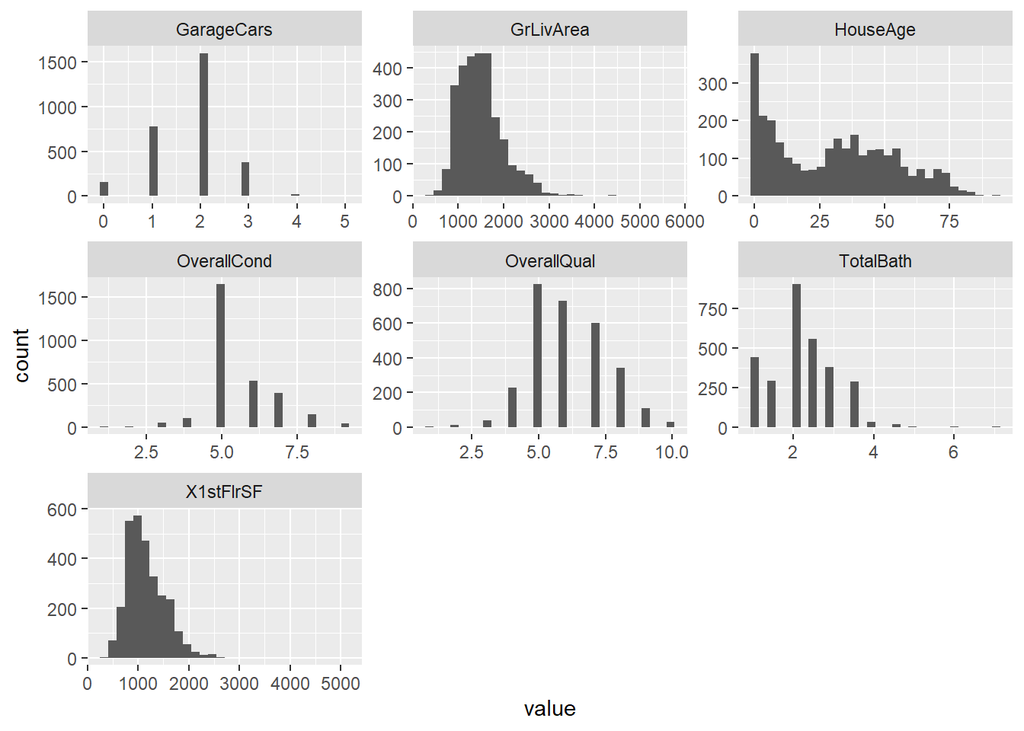

```r
library(ggplot2)
top_10 %>%
  select_if(is.numeric) %>%
  gather() %>%
  ggplot(aes(value)) +
    facet_wrap(~ key, scales = "free") +
    geom_histogram()
```

Most of the numeric variables in top 10 have outliers, they are right-skewed.Deleting outliers is a little tricky, we’ll know the effect of it only after model evaluation. However, there are a few rules that will work effectively most of the time.

1. Remove extreme outliers. (< Median-3*IQR & >Median+3*IQR)
2. Log transformation.

Let’s do log-transformation of all right-skewed numeric variables and not just top 10. If any of the variables are still right-skewed after log, we can remove some outliers from them.

However, I’ll handle outliers after Exploratory Analysis. Let’s see the effect of these outliers visually before removing them or transforming the variables.

## GrLivArea

Above ground living area

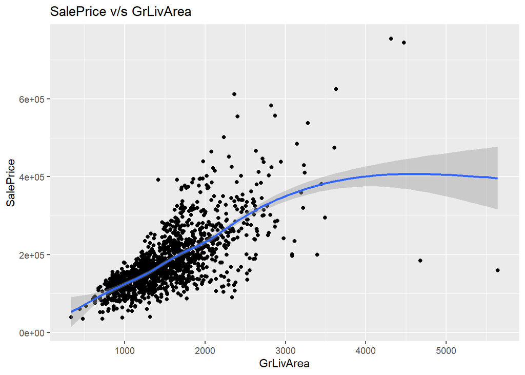

```r
ggplot(data=trainimp,aes(GrLivArea,SalePrice))+geom_point()+labs(title="SalePrice v/s GrLivArea", xlab="Above ground living area", ylab="SalePrice")+stat_smooth()
```

```r
trainimp <- subset(trainimp, GrLivArea<4500)
trainimp <- subset(trainimp, SalePrice<700000)
```

Let’s look athe plot now.

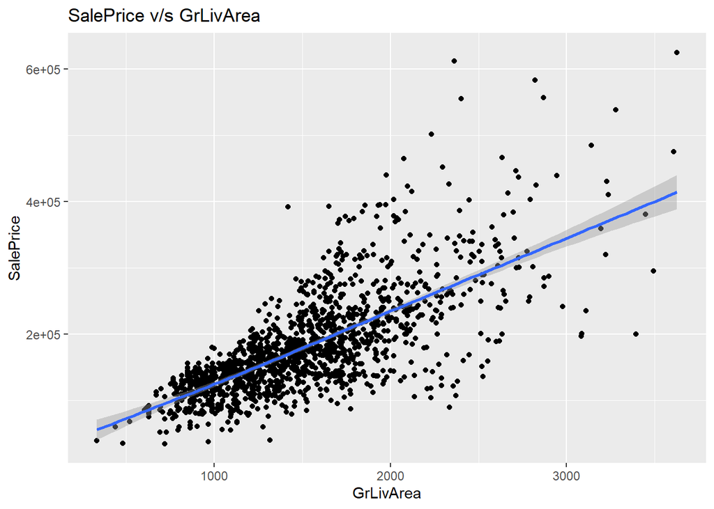

```r
ggplot(data=trainimp,aes(GrLivArea,SalePrice))+geom_point()+labs(title="SalePrice v/s GrLivArea", xlab="Above ground living area", ylab="SalePrice")+stat_smooth()
```

We can say the relationship is strongest when 500 < GrLivArea < 2000

## OverallQual

This is a discrete numeric variable and so using it as a factor and visualizing using boxplot makes better sense.

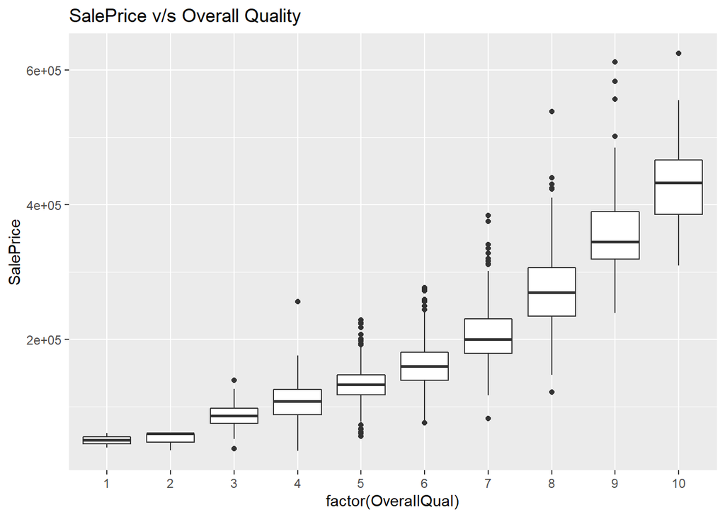

```r
ggplot(data=trainimp,aes(factor(OverallQual),SalePrice))+geom_boxplot()+labs(title="SalePrice v/s Overall Quality", xlab="Overall Quality", ylab="SalePrice")
```

## GarageCars

```r
summary(factor(trainimp$GarageCars))
```

```
##   0   1   2   3   4
##  81 369 823 178   5
```

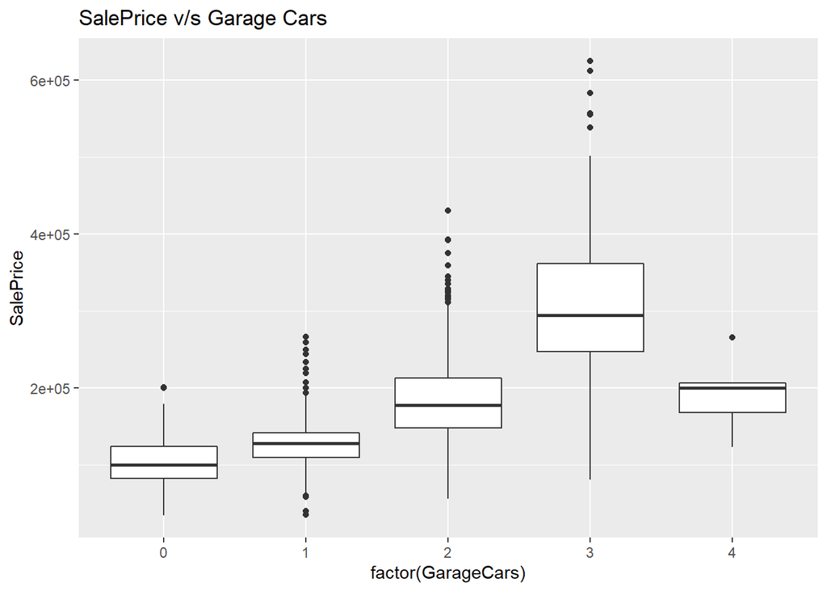

```r
ggplot(data=trainimp,aes(factor(GarageCars),SalePrice))+geom_boxplot()+labs(title="SalePrice v/s Garage Cars", xlab="Garage Cars", ylab="SalePrice")
```

Sale price of houses increased with number of cars. We can ignore GarageCars=4 since it’s only for 5 records.

## TotalBath

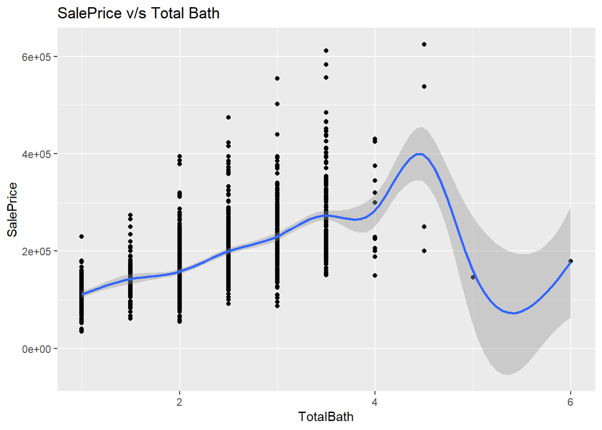

```r
ggplot(data=trainimp,aes(TotalBath,SalePrice))+geom_point()+labs(title="SalePrice v/s Total Bath", xlab="Total Bath", ylab="SalePrice")+stat_smooth()
```

Considering TotalBath is one of the top important variables, we can delete the 2 outliers that are affecting its general relationship with SalePrice.

```r
trainimp <- subset(trainimp, TotalBath<=4.8)
```

## HouseAge

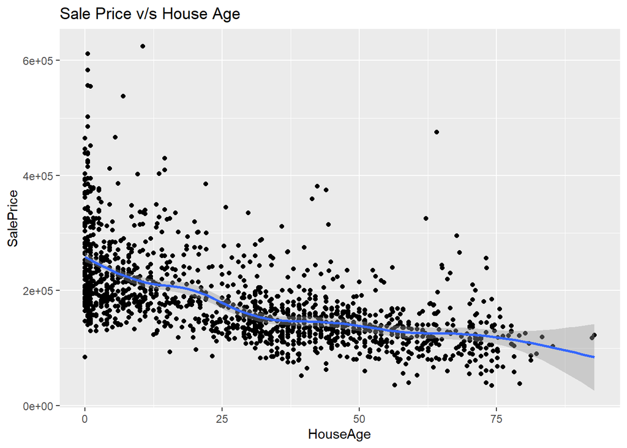

```r
ggplot(data=trainimp,aes(HouseAge,SalePrice))+geom_point()+labs(title="Sale Price v/s House Age", xlab="House Age", ylab="SalePrice")+stat_smooth()
```

As expected, the house prices are high for new homes with the exception of a few outliers. There is one house which is 64 years old and managed to have a high sale price. Let’s look at this house.

The house has overallQual and OverallCond are rated very high and it also has features like Fireplace and Porch Area. So, this is not considered outlier since the price is affected by other features.

```r
subset(trainimp, HouseAge>50 & SalePrice>400000)
```

```
##     MSSubClass MSZoning LotFrontage LotArea Street Alley LotShape
## 186         75       RM          90   22950   Pave  None      IR2
##     LandContour LotConfig LandSlope Neighborhood Condition1 BldgType
## 186         Lvl    Inside       Gtl      OldTown     Artery     1Fam
##     HouseStyle OverallQual OverallCond YearBuilt YearRemodAdd RoofStyle
## 186     2.5Fin          10           9      1892         1993     Gable
##     Exterior1st Exterior2nd MasVnrType MasVnrArea ExterQual ExterCond
## 186     Wd Sdng     Wd Sdng       None          0        Gd        Gd
##     Foundation BsmtQual BsmtCond BsmtExposure BsmtFinType1 BsmtFinSF1
## 186     BrkTil       TA       TA           Mn          Unf          0
##     BsmtFinType2 BsmtFinSF2 BsmtUnfSF TotalBsmtSF Heating HeatingQC
## 186          Unf          0      1107        1107    GasA        Ex
##     CentralAir Electrical X1stFlrSF X2ndFlrSF GrLivArea FullBath
## 186          Y      SBrkr      1518      1518      3608        2
##     BedroomAbvGr KitchenAbvGr KitchenQual TotRmsAbvGrd Functional
## 186            4            1          Ex           12        Typ
##     Fireplaces FireplaceQu GarageType GarageFinish GarageCars GarageArea
## 186          2          TA     Detchd          Unf          3        840
##     GarageQual GarageCond PavedDrive WoodDeckSF OpenPorchSF EnclosedPorch
## 186         Ex         TA          Y          0         260             0
##     ScreenPorch PoolArea PoolQC Fence MiscFeature MiscVal MoSold YrSold
## 186         410        0   None GdPrv        None       0      6   2006
##     SaleType SaleCondition GarageAge TotalBath HouseAge SalePrice
## 186       WD        Normal        13       2.5 64.13553    475000
```

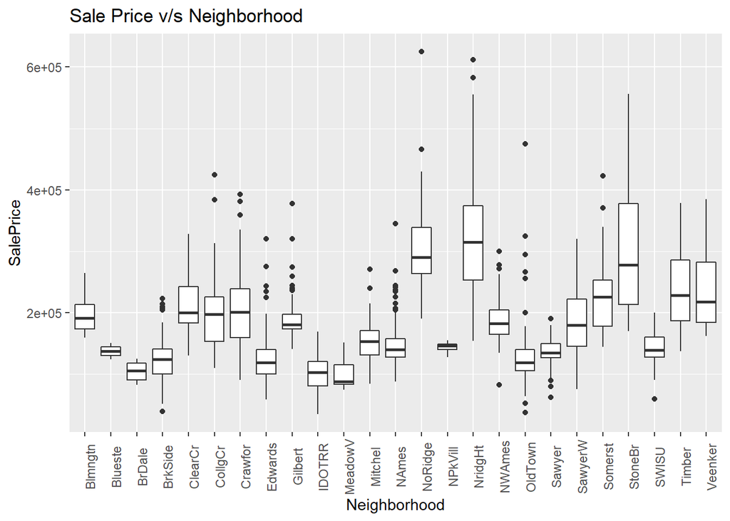

```r
ggplot(data=trainimp,aes(Neighborhood,SalePrice))+geom_boxplot()+labs(title="Sale Price v/s Neighborhood", xlab="Neighborhood", ylab="SalePrice")+ theme(axis.text.x = element_text(angle=90))
```

It’s very clear that some of the neighborhoods like NridgHt, NoRidge are expensive.

## OverallQual v/s OverallCond

It’s very interesting to know that good quality of material doesn’t assure good condition of house. It should depend upon maintenance.

```r
cor(trainimp$OverallCond, trainimp$OverallQual)
```

```
## [1] -0.09037391
```

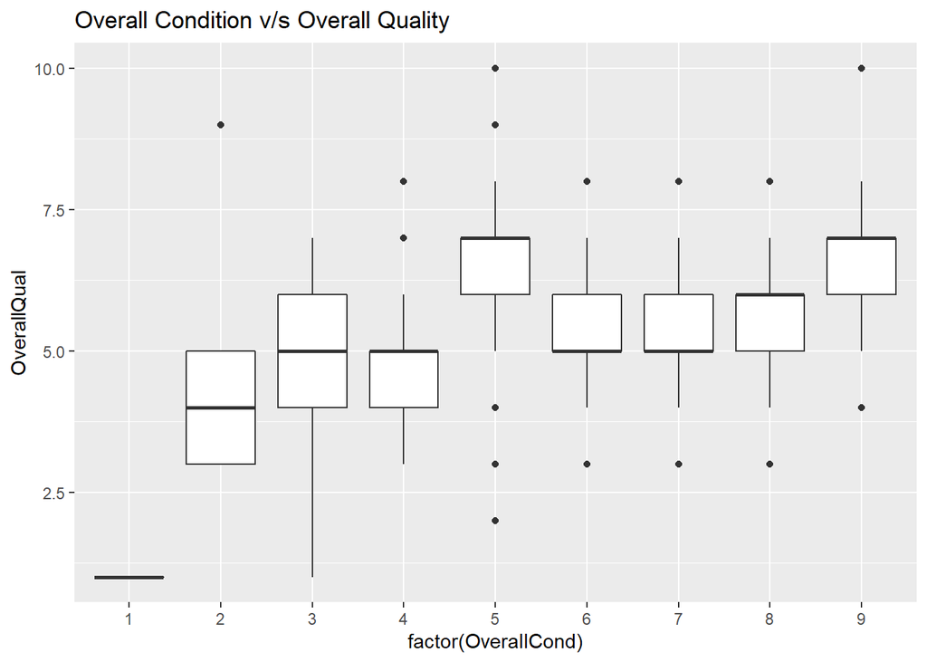

```r
ggplot(data=trainimp,aes(factor(OverallCond),OverallQual))+geom_boxplot()+labs(title="Overall Condition v/s Overall Quality", xlab="OverallCond", ylab="OverallQual")
```

If both of these are good, they should result in high sale price. Let’s check for the interaction.

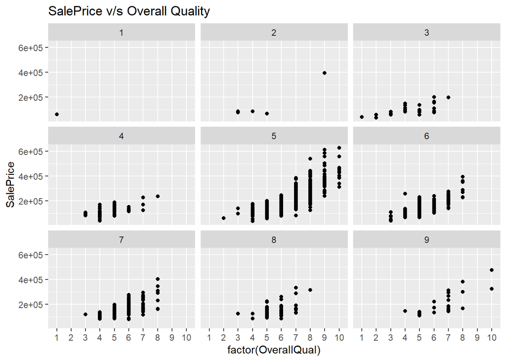

```r
ggplot(data=trainimp,aes(factor(OverallQual),SalePrice))+geom_point()+labs(title="SalePrice v/s Overall Quality", xlab="Overall Quality", ylab="SalePrice")+facet_wrap(~OverallCond)
```

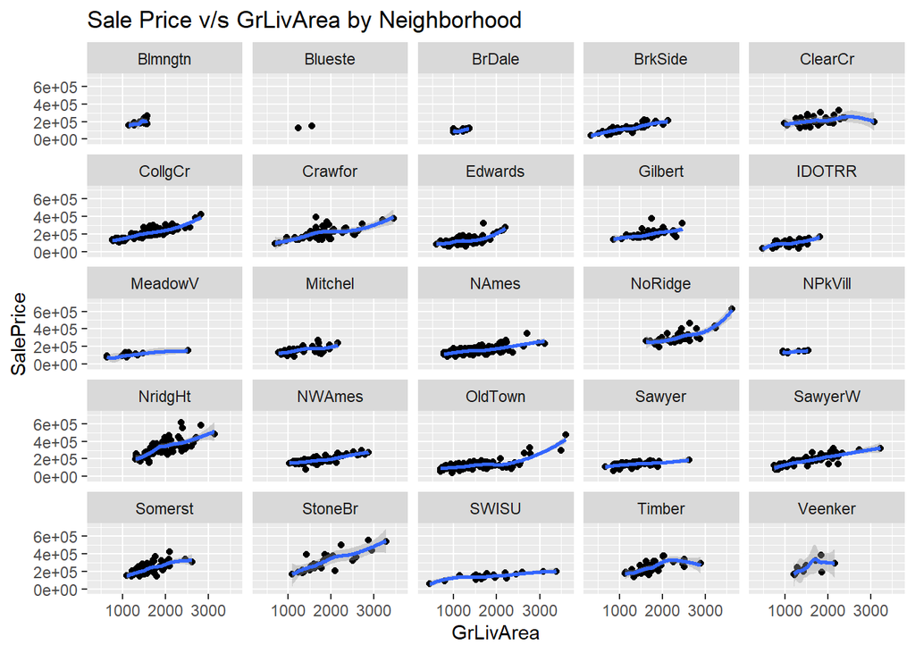

```r
suppressWarnings(ggplot(data=trainimp,aes(GrLivArea,SalePrice))+geom_point()+labs(title="Sale Price v/s GrLivArea by Neighborhood", xlab="GrLivArea", ylab="SalePrice")+facet_wrap(~Neighborhood)+stat_smooth())
```

The above plot shows that the increase in sale price with above ground living area is sharp for NridgHt, StoneBr and SawyerW to some extent.

## SalePrice v/s GrLivArea by BldgType

There is a sharp increase of saleprice with GrLivArea for single family detached homes.

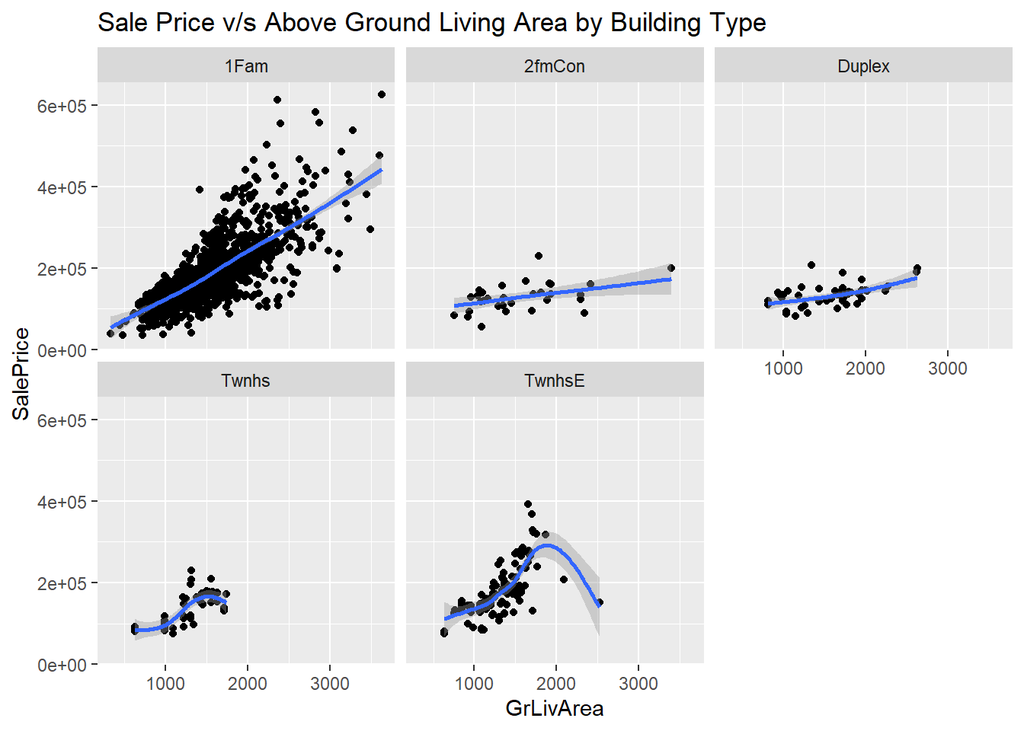

```r
ggplot(data=trainimp,aes(GrLivArea,SalePrice))+geom_point()+labs(title="Sale Price v/s Above Ground Living Area by Building Type", xlab="GrLivArea", ylab="SalePrice")+facet_wrap(~BldgType)+stat_smooth()
```

```r
summary(lm(SalePrice~Neighborhood, trainimp))
```

```
##
## Call:
## lm(formula = SalePrice ~ Neighborhood, data = trainimp)
##
## Residuals:
##     Min      1Q  Median      3Q     Max
## -162271  -26847   -5217   20163  346775
##
## Coefficients:
##                     Estimate Std. Error t value Pr(>|t|)
## (Intercept)           194871      12532  15.550  < 2e-16 ***
## NeighborhoodBlueste   -57371      38627  -1.485 0.137693
## NeighborhoodBrDale    -90377      17998  -5.022 5.77e-07 ***
## NeighborhoodBrkSide   -70037      14251  -4.915 9.92e-07 ***
## NeighborhoodClearCr    17695      15887   1.114 0.265573
## NeighborhoodCollgCr     3095      13223   0.234 0.814980
## NeighborhoodCrawfor    15754      14471   1.089 0.276486
## NeighborhoodEdwards   -68284      13596  -5.022 5.75e-07 ***
## NeighborhoodGilbert    -2016      13815  -0.146 0.883976
## NeighborhoodIDOTRR    -94747      15140  -6.258 5.14e-10 ***
## NeighborhoodMeadowV   -96294      17723  -5.433 6.50e-08 ***
## NeighborhoodMitchel   -38601      14544  -2.654 0.008043 **
## NeighborhoodNAmes     -49024      12997  -3.772 0.000169 ***
## NeighborhoodNoRidge   119158      15017   7.935 4.23e-15 ***
## NeighborhoodNPkVill   -52176      21301  -2.450 0.014423 *
## NeighborhoodNridgHt   121400      13847   8.767  < 2e-16 ***
## NeighborhoodNWAmes     -5821      13915  -0.418 0.675782
## NeighborhoodOldTown   -66646      13442  -4.958 7.97e-07 ***
## NeighborhoodSawyer    -58078      13897  -4.179 3.10e-05 ***
## NeighborhoodSawyerW    -8315      14223  -0.585 0.558906
## NeighborhoodSomerst    30509      13715   2.225 0.026270 *
## NeighborhoodStoneBr   115628      16244   7.118 1.72e-12 ***
## NeighborhoodSWISU     -52280      16244  -3.218 0.001318 **
## NeighborhoodTimber     47377      15077   3.142 0.001711 **
## NeighborhoodVeenker    43902      19994   2.196 0.028273 *
## ---
## Signif. codes:  0 '***' 0.001 '**' 0.01 '*' 0.05 '.' 0.1 ' ' 1
##
## Residual standard error: 51670 on 1429 degrees of freedom
## Multiple R-squared:  0.5542, Adjusted R-squared:  0.5467
## F-statistic: 74.01 on 24 and 1429 DF,  p-value: < 2.2e-16
```

```r
summary(lm(SalePrice~GrLivArea, trainimp))
```

```
##
## Call:
## lm(formula = SalePrice ~ GrLivArea, data = trainimp)
##
## Residuals:
##     Min      1Q  Median      3Q     Max
## -190724  -29788    -596   22462  335863
##
## Coefficients:
##              Estimate Std. Error t value Pr(>|t|)
## (Intercept) 12268.829   4451.822   2.756  0.00593 **
## GrLivArea     111.474      2.807  39.713  < 2e-16 ***
## ---
## Signif. codes:  0 '***' 0.001 '**' 0.01 '*' 0.05 '.' 0.1 ' ' 1
##
## Residual standard error: 53150 on 1452 degrees of freedom
## Multiple R-squared:  0.5207, Adjusted R-squared:  0.5203
## F-statistic:  1577 on 1 and 1452 DF,  p-value: < 2.2e-16
```

```r
summary(lm(SalePrice~GrLivArea+Neighborhood, trainimp))
```

```
##
## Call:
## lm(formula = SalePrice ~ GrLivArea + Neighborhood, data = trainimp)
##
## Residuals:
##     Min      1Q  Median      3Q     Max
## -138480  -20623     128   17328  258623
##
## Coefficients:
##                       Estimate Std. Error t value Pr(>|t|)
## (Intercept)          77706.811   9941.223   7.817 1.05e-14 ***
## GrLivArea               82.051      2.416  33.967  < 2e-16 ***
## NeighborhoodBlueste -54462.897  28737.422  -1.895 0.058269 .
## NeighborhoodBrDale  -67012.795  13407.671  -4.998 6.51e-07 ***
## NeighborhoodBrkSide -51585.830  10616.222  -4.859 1.31e-06 ***
## NeighborhoodClearCr -11857.449  11851.810  -1.000 0.317250
## NeighborhoodCollgCr  -1217.616   9838.590  -0.124 0.901523
## NeighborhoodCrawfor -14085.388  10801.759  -1.304 0.192447
## NeighborhoodEdwards -53928.399  10124.333  -5.327 1.16e-07 ***
## NeighborhoodGilbert -19524.041  10290.858  -1.897 0.058000 .
## NeighborhoodIDOTRR  -71309.719  11284.790  -6.319 3.51e-10 ***
## NeighborhoodMeadowV -66017.575  13215.670  -4.995 6.60e-07 ***
## NeighborhoodMitchel -27627.491  10825.588  -2.552 0.010812 *
## NeighborhoodNAmes   -39372.132   9673.596  -4.070 4.96e-05 ***
## NeighborhoodNoRidge  38408.158  11422.510   3.362 0.000793 ***
## NeighborhoodNPkVill -37822.331  15852.723  -2.386 0.017169 *
## NeighborhoodNridgHt  81358.265  10368.782   7.846 8.33e-15 ***
## NeighborhoodNWAmes  -30422.971  10377.775  -2.932 0.003426 **
## NeighborhoodOldTown -70894.553  10001.163  -7.089 2.12e-12 ***
## NeighborhoodSawyer  -40616.788  10352.019  -3.924 9.14e-05 ***
## NeighborhoodSawyerW -22023.828  10589.623  -2.080 0.037726 *
## NeighborhoodSomerst  16666.124  10211.737   1.632 0.102888
## NeighborhoodStoneBr  78611.704  12133.817   6.479 1.27e-10 ***
## NeighborhoodSWISU   -82909.082  12118.376  -6.842 1.16e-11 ***
## NeighborhoodTimber   21003.123  11243.761   1.868 0.061970 .
## NeighborhoodVeenker  34737.138  14877.782   2.335 0.019690 *
## ---
## Signif. codes:  0 '***' 0.001 '**' 0.01 '*' 0.05 '.' 0.1 ' ' 1
##
## Residual standard error: 38440 on 1428 degrees of freedom
## Multiple R-squared:  0.7534, Adjusted R-squared:  0.7491
## F-statistic: 174.5 on 25 and 1428 DF,  p-value: < 2.2e-16
```

```r
summary(lm(SalePrice~GrLivArea*Neighborhood, trainimp))
```

```
##
## Call:
## lm(formula = SalePrice ~ GrLivArea * Neighborhood, data = trainimp)
##
## Residuals:
##     Min      1Q  Median      3Q     Max
## -136862  -19279    -629   15325  219585
##
## Coefficients:
##                                 Estimate Std. Error t value Pr(>|t|)
## (Intercept)                    15133.285  92609.222   0.163   0.8702
## GrLivArea                        125.872     64.571   1.949   0.0515 .
## NeighborhoodBlueste             7389.651 235390.959   0.031   0.9750
## NeighborhoodBrDale             18820.752 115005.063   0.164   0.8700
## NeighborhoodBrkSide             4838.229  93887.237   0.052   0.9589
## NeighborhoodClearCr           135938.743  96503.124   1.409   0.1592
## NeighborhoodCollgCr            30156.150  93197.955   0.324   0.7463
## NeighborhoodCrawfor            42264.673  94218.863   0.449   0.6538
## NeighborhoodEdwards            10434.072  93624.143   0.111   0.9113
## NeighborhoodGilbert            62461.164  95336.481   0.655   0.5125
## NeighborhoodIDOTRR              9606.918  95831.520   0.100   0.9202
## NeighborhoodMeadowV            43901.283  95136.895   0.461   0.6445
## NeighborhoodMitchel            68949.590  94415.157   0.730   0.4653
## NeighborhoodNAmes              59543.117  92947.448   0.641   0.5219
## NeighborhoodNoRidge           -36082.963  98719.720  -0.366   0.7148
## NeighborhoodNPkVill            88183.321 114669.099   0.769   0.4420
## NeighborhoodNridgHt           -23001.767  94499.058  -0.243   0.8077
## NeighborhoodNWAmes             55880.413  94332.141   0.592   0.5537
## NeighborhoodOldTown            19208.602  93072.815   0.206   0.8365
## NeighborhoodSawyer             79907.882  93864.823   0.851   0.3947
## NeighborhoodSawyerW            28331.536  93885.904   0.302   0.7629
## NeighborhoodSomerst             -285.013  95028.589  -0.003   0.9976
## NeighborhoodStoneBr            -6320.276  95930.797  -0.066   0.9475
## NeighborhoodSWISU              53797.751  95173.670   0.565   0.5720
## NeighborhoodTimber             52998.431  96421.272   0.550   0.5826
## NeighborhoodVeenker            -3566.812 108420.005  -0.033   0.9738
## GrLivArea:NeighborhoodBlueste    -43.303    167.312  -0.259   0.7958
## GrLivArea:NeighborhoodBrDale     -64.167     87.558  -0.733   0.4638
## GrLivArea:NeighborhoodBrkSide    -38.709     65.719  -0.589   0.5559
## GrLivArea:NeighborhoodClearCr    -91.482     66.223  -1.381   0.1674
```

[output cut: 11 more lines]

```
## GrLivArea:NeighborhoodNWAmes     -57.555     65.357  -0.881   0.3787
## GrLivArea:NeighborhoodOldTown    -62.425     64.835  -0.963   0.3358
## GrLivArea:NeighborhoodSawyer     -91.512     65.699  -1.393   0.1639
## GrLivArea:NeighborhoodSawyerW    -36.161     65.227  -0.554   0.5794
## GrLivArea:NeighborhoodSomerst      5.986     65.892   0.091   0.9276
## GrLivArea:NeighborhoodStoneBr     34.678     65.821   0.527   0.5984
## GrLivArea:NeighborhoodSWISU      -84.978     65.591  -1.296   0.1953
## GrLivArea:NeighborhoodTimber     -26.341     66.287  -0.397   0.6911
## GrLivArea:NeighborhoodVeenker     21.700     73.901   0.294   0.7691
## ---
## Signif. codes:  0 '***' 0.001 '**' 0.01 '*' 0.05 '.' 0.1 ' ' 1
##
## Residual standard error: 35690 on 1404 degrees of freedom
## Multiple R-squared:  0.791,  Adjusted R-squared:  0.7837
## F-statistic: 108.5 on 49 and 1404 DF,  p-value: < 2.2e-16
```

Note that we have removed some rows in trainimp and the new trainimp has 1454 rows instead of 1460.

```r
dataimp <- rbind(trainimp[,-74],testimp)
SalePrice <- trainimp[,74]
```

# Getting data ready for building model

## Handling Skewness

Skewness Coefficient:

> 1 or <-1 : Heavily skewed 0.5 to 1 or -1 to -0.5 : Moderately skewed. -0.5 to 0.5 : Normal distrbution.

For example, let’s check for the target variable in train data.

```r
library(e1071)
skewness(trainimp$SalePrice)
```

```
## [1] 1.56109
```

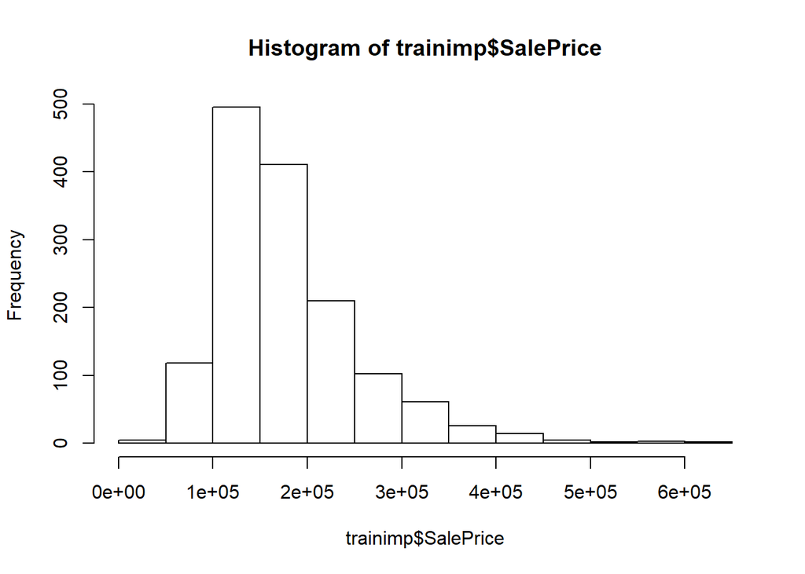

```r
hist(trainimp$SalePrice)
```

SalePrice is heavily right(positive coefficient) skewed. We need to perform log transformation on it. If a variable is left-skewed, we need to do square-root transformation.

One more thing that we need to decide is upper and lower limits for skewness. Although -0.5 to 0.5 is the theoretical interval, moderate skewness can be accepted too. Let’s look at the below variable.

```r
skewness(dataimp$OverallCond)
```

```
## [1] 0.5693313
```

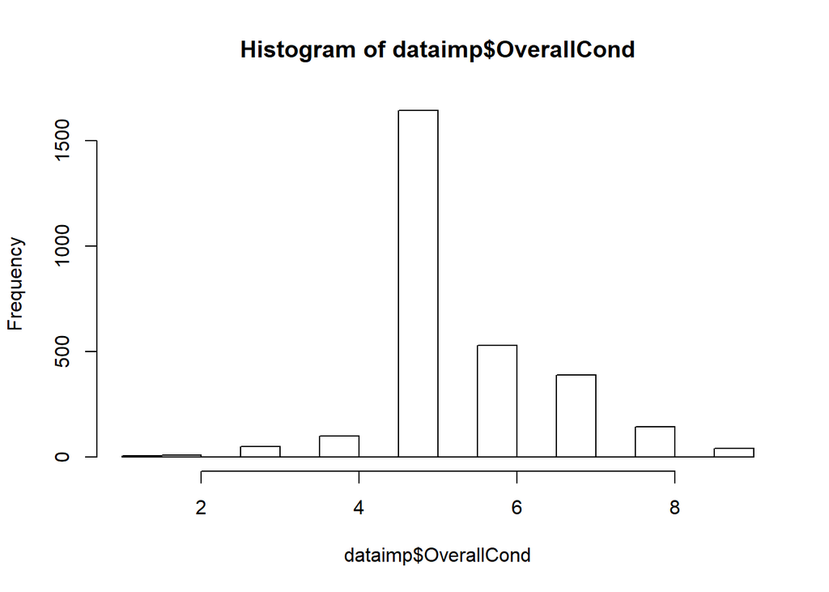

```r
hist(dataimp$OverallCond)
```

Skewness coefficient is 0.57 but it’s not very skewed. So, I decide to accept skewness between -0.75 and 0.75.

Let’s calculate skewness of each and every variable and let’s make transformations based on these values.

```r
library(fBasics)
library(dplyr)
dataimp%>%
  select_if(is.numeric) %>%
  colSkewness()
```

```
##   LotFrontage       LotArea   OverallQual   OverallCond     YearBuilt
##     0.9963187    13.1126638     0.1805835     0.5693313    -0.5968216
##  YearRemodAdd    MasVnrArea    BsmtFinSF1    BsmtFinSF2     BsmtUnfSF
##    -0.4480629     2.5797374     0.9763156     4.1390894     0.9182089
##   TotalBsmtSF     X1stFlrSF     X2ndFlrSF     GrLivArea      FullBath
##     0.6568957     1.2524174     0.8434875     0.9781578     0.1576606
##  BedroomAbvGr  KitchenAbvGr  TotRmsAbvGrd    Fireplaces    GarageCars
##     0.3288637     4.3132793     0.7497998     0.7246128    -0.2147479
##    GarageArea    WoodDeckSF   OpenPorchSF EnclosedPorch   ScreenPorch
##     0.2237748     1.8468508     2.5276002     3.9971889     3.9398847
##      PoolArea       MiscVal        YrSold     GarageAge     TotalBath
##    18.6857312    21.9133304     0.1301701     0.7068814     0.4491512
##      HouseAge
##     0.2992377
```

Let’s make vectors of all variables based on skewness. We only have right-skewed variables.

```r
right_skew <- c("LotFrontage","LotArea", "MasVnrArea", "BsmtFinSF1", "BsmtFinSF2","BsmtUnfSF","X1stFlrSF","X2ndFlrSF","GrLivArea","KitchenAbvGr", "WoodDeckSF", "OpenPorchSF","PoolArea","EnclosedPorch","ScreenPorch","MiscVal")
```

These should be log-transformed. However, before that, we have to think about the complications with log and sqrt transformations. Log of any value below or equal to 0 doesn’t exist, it will result in NaN values in our predictions. Also, log of any value between 0 and 1 will be negative and working on negative values might also result in NaN values based on the functions we use. And we know that square root of negative numbers is indefinite. From the summary of the data, it’s evident that there are no negative values but there are a lot of zeroes. So, let’s add 1.1 to values to keep them above 1 before log transformation. We don’t have any problem for square root transformation.

Let’s compare the skew of these variables before and after log transformation. Most of these still seem to be right-skewed but the extent of skewness decreased. I will remove Lotfrontage, BsmtUnfSF from my right-skew list because log transformation is making them negatively-skewed.

```r
dataimp[,right_skew]%>%
  colSkewness()
```

```
##   LotFrontage       LotArea    MasVnrArea    BsmtFinSF1    BsmtFinSF2
##     0.9963187    13.1126638     2.5797374     0.9763156     4.1390894
##     BsmtUnfSF     X1stFlrSF     X2ndFlrSF     GrLivArea  KitchenAbvGr
##     0.9182089     1.2524174     0.8434875     0.9781578     4.3132793
##    WoodDeckSF   OpenPorchSF      PoolArea EnclosedPorch   ScreenPorch
##     1.8468508     2.5276002    18.6857312     3.9971889     3.9398847
##       MiscVal
##    21.9133304
```

```r
log(dataimp[,right_skew]+1.1)%>%
  colSkewness()
```

```
##   LotFrontage       LotArea    MasVnrArea    BsmtFinSF1    BsmtFinSF2
##   -1.03237976   -0.53215828    0.50926541   -0.61039079    2.46073171
##     BsmtUnfSF     X1stFlrSF     X2ndFlrSF     GrLivArea  KitchenAbvGr
##   -2.12854643    0.02606309    0.30858902   -0.04455627    3.59085181
##    WoodDeckSF   OpenPorchSF      PoolArea EnclosedPorch   ScreenPorch
##    0.16331551   -0.03320048   16.32244021    1.95945285    2.94148770
##       MiscVal
##    5.21053141
```

```r
right_skew <- c("LotArea", "MasVnrArea", "BsmtFinSF1", "BsmtFinSF2","X1stFlrSF","X2ndFlrSF","GrLivArea","KitchenAbvGr", "WoodDeckSF", "OpenPorchSF","EnclosedPorch","ScreenPorch","PoolArea","MiscVal")

dataimp[,right_skew] <- log(dataimp[,right_skew]+1.1)
```

## Multicollinearity

From the correlation matrix of all numeric variables, it’s seen that there is multicollinearity issue. I want to use principal component analysis to remove multicollinearity. We will lose the original predictors but we don’t need them, we only need the prediction accuracy to be as high as possible.

Multicollinearity can be detected to some extent by using the following functions from dataPreparation() package.

```r
library(dataPreparation)
whichAreBijection(dataimp)
```

```
## [1] "whichAreBijection: it took me 8.87s to identify 0 column(s) to drop."
```

```
## integer(0)
```

```r
whichAreIncluded(dataimp)
```

```
## [1] "whichAreIncluded: PoolQC is included in column PoolArea."
```

```
## [1] 63
```

```r
whichAreInDouble(dataimp)
```

```
## [1] "whichAreInDouble: it took me 0.08s to identify 0 column(s) to drop."
```

```
## integer(0)
```

```r
whichAreConstant(dataimp)
```

```
## [1] "whichAreConstant: it took me 0.03s to identify 0 constant column(s)"
```

```
## integer(0)
```

Let’s delete the variables from the above result

```r
dataimp <- subset(dataimp, select=-PoolQC)
```

## Principal Component Analysis

To perform principle component analysis, we need all variables to be numeric. So, we have to one hot encode all factor variables to make them numeric. And before that, let’s standardize all the numeric predictors.

## Standardization

To do this, we need to separate train and test to avoid data snooping. We don’t need the target variable in train data at this point.

```r
trainimp <- dataimp[1:1454,]
testimp <- dataimp[1455:2913,]
```

```r
scales <- build_scales(dataSet = trainimp,
cols = "auto", verbose = FALSE)
train_scaled <- fastScale(dataSet = trainimp,
scales = scales, verbose = FALSE)
scales <- build_scales(dataSet = testimp,
cols = "auto", verbose = FALSE)
test_scaled <- fastScale(dataSet = testimp,
scales = scales, verbose = FALSE)
```

Now let’s combine train and test for one hot encoding. the reason for joining train and test is so that they have same number of variables. If the number of levels is different between them, one hot encoding separately will result in different number of columns.

```r
data_scaled <- rbind(train_scaled,test_scaled)
```

## Creating dummies

```r
library(fastDummies)
data_dummy <- dummy_cols(data_scaled, remove_first_dummy = TRUE)
```

The above code results in a dataframe that has n-1 dummies from each factor variable but it also has the initial factor variabls which are dummied. We need to remove the initial factor variables. Ordered factors are not converted to dummies.

Below are the factor variables, but they also have ordered factors which shouldn’t be removed.

```r
names(data_dummy)[sapply(data_dummy, is.factor)]
```

```
##  [1] "MSSubClass"    "MSZoning"      "Street"        "Alley"
##  [5] "LotShape"      "LandContour"   "LotConfig"     "LandSlope"
##  [9] "Neighborhood"  "Condition1"    "BldgType"      "HouseStyle"
## [13] "RoofStyle"     "Exterior1st"   "Exterior2nd"   "MasVnrType"
## [17] "ExterQual"     "ExterCond"     "Foundation"    "BsmtQual"
## [21] "BsmtCond"      "BsmtExposure"  "BsmtFinType1"  "BsmtFinType2"
## [25] "Heating"       "HeatingQC"     "CentralAir"    "Electrical"
## [29] "KitchenQual"   "Functional"    "FireplaceQu"   "GarageType"
## [33] "GarageFinish"  "GarageQual"    "GarageCond"    "PavedDrive"
## [37] "Fence"         "MiscFeature"   "MoSold"        "SaleType"
## [41] "SaleCondition"
```

I’m manually making a vector of the names of factors that need to be removed.

```r
factors_to_be_removed <- c("MSSubClass","MSZoning","Street","Alley","LotShape","LandContour", "LotConfig","LandSlope","Neighborhood","Condition1","BldgType","HouseStyle", "RoofStyle","Exterior1st","Exterior2nd","MasVnrType","Foundation","Heating", "CentralAir","Electrical","Functional","GarageType","GarageFinish","PavedDrive","Fence","MiscFeature","MoSold","SaleType","SaleCondition") #for future use if any

data_dummy<- subset(data_dummy, select = -c(MSSubClass,MSZoning,Street,Alley,LotShape,LandContour,LotConfig,LandSlope, Neighborhood,Condition1,BldgType,HouseStyle,RoofStyle,Exterior1st,Exterior2nd, MasVnrType,Foundation,Heating,CentralAir,Electrical,Functional,GarageType, GarageFinish,PavedDrive,Fence,MiscFeature,MoSold,SaleType,SaleCondition))
```

Let’s check for inclusions, constants, bijections and doubles again.

```r
whichAreBijection(data_dummy)
```

```
## [1] "whichAreBijection: BldgType_Duplex is a bijection of MSSubClass_90. I put it in drop list."
## [1] "whichAreBijection: it took me 155.51s to identify 1 column(s) to drop."
```

```
## [1] 111
```

```r
whichAreIncluded(data_dummy)
```

```
## [1] "whichAreIncluded: MSSubClass_90 is included in column BldgType_Duplex."
## [1] "whichAreIncluded: MSSubClass_150 is included in column LotFrontage."
## [1] "whichAreIncluded: LotConfig_FR3 is included in column LotArea."
## [1] "whichAreIncluded: Neighborhood_Blueste is included in column LotArea."
## [1] "whichAreIncluded: HouseStyle_2.5Fin is included in column HouseAge."
## [1] "whichAreIncluded: RoofStyle_Shed is included in column LotArea."
## [1] "whichAreIncluded: Exterior1st_CBlock is included in column GrLivArea."
## [1] "whichAreIncluded: Exterior1st_ImStucc is included in column GarageArea."
## [1] "whichAreIncluded: Exterior1st_Stone is included in column EnclosedPorch."
## [1] "whichAreIncluded: Exterior2nd_Other is included in column BsmtFinSF1."
## [1] "whichAreIncluded: Heating_OthW is included in column YearBuilt."
## [1] "whichAreIncluded: Electrical_Mix is included in column TotalBsmtSF."
## [1] "whichAreIncluded: Functional_Sev is included in column HouseAge."
## [1] "whichAreIncluded: GarageType_None is included in column GarageCars."
## [1] "whichAreIncluded: GarageFinish_None is included in column GarageQual."
## [1] "whichAreIncluded: MiscFeature_Othr is included in column LotArea."
## [1] "whichAreIncluded: MiscFeature_TenC is included in column PoolArea."
```

```
##  [1]  53  55  74  78 116 125 129 132 135 148 166 171 177 184 185 195 197
```

```r
whichAreConstant(data_dummy)
```

```
## [1] "whichAreConstant: it took me 0.05s to identify 0 constant column(s)"
```

```
## integer(0)
```

```r
whichAreInDouble(data_dummy)
```

```
## [1] "whichAreInDouble: BldgType_Duplex is exactly equal to MSSubClass_90. I put it in drop list."
## [1] "whichAreInDouble: it took me 0.69s to identify 1 column(s) to drop."
```

```
## [1] 111
```

Removing the duplicate columns

```r
data_dummy <- subset(data_dummy,select = -c(BldgType_Duplex,MSSubClass_150,LotConfig_FR3, Neighborhood_Blueste,HouseStyle_2.5Fin,RoofStyle_Shed,Exterior1st_CBlock,Exterior1st_ImStucc, Exterior1st_Stone,Exterior2nd_Other,Heating_OthW,Electrical_Mix, Functional_Sev, GarageType_None, GarageFinish_None, MiscFeature_Othr,MiscFeature_TenC))
```

## Near zero variance

Let’s look for near zero variance variables and remove them.

```r
library(caret)
nearZeroVar(data_dummy, freqCut = 99/1)
```

```
##  [1]  45  46  50  56  59  62  66  75  88  98 101 103 105 106 110 112 117
## [18] 119 120 121 131 132 134 137 140 151 152 154 155 156 159 161 169 177
## [35] 192 193 194 195 196 198 200 201
```

Removing by column numbers

```r
data_dummy <- data_dummy[,-c(45,46,50,56,59,62,66,75,88,98,101,103,105,106,110, 112,117,119,120,121,131,132,134,137,140,151,152,154,155,156,159,161,169,177,192:196,198,200,201)]
```

Let’s finally split the data into train and test sets.

```r
train_final <- cbind(data_dummy[1:1454,],SalePrice=SalePrice)
test_final <- data_dummy[1455:2913,]
```

## PCA

```r
preproc <- preProcess(train_final[,-163], method='pca', thresh=0.99) #use the PCA preprocess
train.pca <- predict(preproc, train_final[,-163])
test.pca <- predict(preproc, test_final)

dim(train.pca)
```

```
## [1] 1454  131
```

```r
dim(test.pca)
```

```
## [1] 1459  131
```

```r
train.pca <- cbind(train.pca,SalePrice)

summary(train.pca$SalePrice)
```

```
##    Min. 1st Qu.  Median    Mean 3rd Qu.    Max.
##   34900  129900  163000  180176  214000  625000
```

```r
quantile(train.pca$SalePrice,0.99)
```

```
##      99%
## 437918.2
```

```r
backup <-train.pca
train.pca <- subset(train.pca, SalePrice<=437919)
Saleprice.pca <- train.pca[,129]
```

Now train.pca has 1439 observations.

## glmnet

```r
library(caret)
set.seed(1234)
tc = trainControl("repeatedcv", number = 10, repeats = 10)

model <-train(log(SalePrice)~.,
              data = train.pca,
              method = "glmnet",
              trControl = tc)
model
```

```
## glmnet
##
## 1439 samples
##  131 predictor
##
## No pre-processing
## Resampling: Cross-Validated (10 fold, repeated 10 times)
## Summary of sample sizes: 1294, 1296, 1295, 1297, 1295, 1294, ...
## Resampling results across tuning parameters:
##
##   alpha  lambda        RMSE       Rsquared   MAE
##   0.10   0.0006308148  0.1157840  0.9085847  0.08096195
##   0.10   0.0063081475  0.1155648  0.9088969  0.08081499
##   0.10   0.0630814754  0.1375626  0.8783858  0.09867440
##   0.55   0.0006308148  0.1150659  0.9096818  0.08037775
##   0.55   0.0063081475  0.1168056  0.9076812  0.08162473
##   0.55   0.0630814754  0.1735031  0.8199051  0.12226137
##   1.00   0.0006308148  0.1145986  0.9103887  0.08001819
##   1.00   0.0063081475  0.1227567  0.8987956  0.08633234
##   1.00   0.0630814754  0.2009581  0.7617989  0.14361123
##
## RMSE was used to select the optimal model using the smallest value.
## The final values used for the model were alpha = 1 and lambda
##  = 0.0006308148.
```

## glmnet Prediction

```r
pricePredict <- predict(model, newdata=test.pca)
#converting data in to regular scale
salePriceVals <- exp(pricePredict)
#Writing predictions to a file to submit to Kaggle
submittestData <- read.csv(file="test.csv",stringsAsFactors = F)
submittestData <- cbind(submittestData,salePriceVals) # Dont run multiple times new change
write.csv(data.frame(Id=submittestData$Id,SalePrice=submittestData$salePriceVals),'SubmissionsFinal.csv')

# Kaggle Score = 0.12340
```